# Tutorial on the Data Science Pipeline: Examining Cancer Survival Status

**Author: Michelle**

This tutorial will walk you through the Data Science Pipeline. Here are the following steps of the pipeline:

1. Data collection/curation
2. Data management/representation
3. Exploratory data analysis
4. Hypothesis testing and machine learning
5. Communication of insights attained

According to the [CDC](https://www.cdc.gov/cancer/breast/statistics/index.htm), breast cancer is the second most common cancer for women in the U.S. The [American Cancer Society](https://www.cancer.org/cancer/breast-cancer/about/how-common-is-breast-cancer.html) predicts that in 2021, about 43,600 women will die from breast cancer. It is therefore worthwhile to explore this topic more.

For this tutoral, we will be working with the **Haberman's Survival Data Set** in order to study survival status in breast cancer patients. This dataset contains information on patients who had undergone breast cancer surgery at the University of Chicago's Billings Hospital between 1958 - 1970. We will try to use variables in this dataset to predict survival status in patients. For more information about the dataset, see the [UCI website here.](https://archive.ics.uci.edu/ml/datasets/haberman's+survival)

Before anything else, we will start off by importing various modules that will be useful for our subsequent analyses

```python
#For general data operations
import pandas as pd
import numpy as np

#For creating figures
import matplotlib.pyplot as plt

#For statistical analysis
from scipy import stats
import math
import statsmodels.api as sm

#For machine learning
from sklearn.linear_model import LogisticRegression
import sklearn.metrics as met
from sklearn.model_selection import KFold

#Supress warnings for the sake of getting clean output
import warnings
warnings.filterwarnings('ignore')
```

## Step 1: Data Collection/Curation

In this step of the data science pipeline, we will obtain the data and read it into our script. The dataset can be downloaded [here.](https://archive.ics.uci.edu/ml/datasets/haberman's+survival)

The dataset is in a comma-separated value format, so we will use a function from [pandas](https://pandas.pydata.org/docs/reference/index.html) to import it. From the UCI website, we can also see that the data has the following attributes, which we can use to label the colummns:

1. Age of patient at time of operation (numerical)
2. Patient's year of operation (year - 1900, numerical)
3. Number of positive axillary nodes detected (numerical)
4. Survival status (class attribute)
   - 1 = the patient survived 5 years or longer
   - 2 = the patient died within 5 years

```python
#Use pandas to read in the csv file
data = pd.read_csv("haberman.csv", names = ["age", "year_op", "nodes", "surv"])

#Display first few rows of dataset to get a preview
data
```

|  | age | year_op | nodes | surv |
| --- | --- | --- | --- | --- |
| 0 | 30 | 64 | 1 | 1 |
| 1 | 30 | 62 | 3 | 1 |
| 2 | 30 | 65 | 0 | 1 |
| 3 | 31 | 59 | 2 | 1 |
| 4 | 31 | 65 | 4 | 1 |
| ... | ... | ... | ... | ... |
| 301 | 75 | 62 | 1 | 1 |
| 302 | 76 | 67 | 0 | 1 |
| 303 | 77 | 65 | 3 | 1 |
| 304 | 78 | 65 | 1 | 2 |
| 305 | 83 | 58 | 2 | 2 |

306 rows × 4 columns

We will be examining the relationship between survival status and the rest of the 3 variables available in this dataset.

Let's check the dimensions of our dataset to see how many patients are in the data:

```python
#Get rows, columns for data frame
data.shape
```

```
(306, 4)
```

We have data on 306 patients, with 4 variables for each person. The greater the number of patients, the greater the [statistical power](https://en.wikipedia.org/wiki/Power_of_a_test) we have for our analyses later, decreasing the chance of making a [type II error](https://en.wikipedia.org/wiki/Type_I_and_type_II_errors). Having over 300 patients should be enough for this tutorial.

## Step 2: Data management/representation

Here we will do some data wrangling. This will make the representation behind some variables more clear and help us get the information in the proper format for our analysis later.

### Missing Data

The UCI website said that there is no missing data, but let's just double check that to make sure

```python
#Checking for any null values
data.isnull().values.any()
```

```
False
```

There does not appear to be any missing data, so we do not have to deal with that issue

### Data Types

Let's make sure each column is the correct type we want it to be. It is important the numeric values are encoded as numeric data types, instead of strings, so that we can obtain statistics on these numbers later.

```python
data.dtypes
```

```
age        int64
year_op    int64
nodes      int64
surv       int64
dtype: object
```

The data types of each column appear to be appropriate. Note that survival status is a categorical outcome, but it can be encoded as an integer.

### Operation Year

Currently, year of operation is listed as year - 1900, but let's change this to get the actual year for the sake of clarity. This way, others don't have to look at the documentation for this dataset to understand what the year represents.

```python
#Add 1900 to each year
data['year_op'] = data['year_op'] + 1900

#Preview changes
data.head()
```

|  | age | year_op | nodes | surv |
| --- | --- | --- | --- | --- |
| 0 | 30 | 1964 | 1 | 1 |
| 1 | 30 | 1962 | 3 | 1 |
| 2 | 30 | 1965 | 0 | 1 |
| 3 | 31 | 1959 | 2 | 1 |
| 4 | 31 | 1965 | 4 | 1 |

### Positive auxillary nodes

[Lymph nodes](https://www.cancer.org/cancer/cancer-basics/lymph-nodes-and-cancer.html) are how cancer cells can spread to the rest of the body, which increases risk of death. Because a cancerous lymph node is a potential indicator of cancer metastasis, there is a large difference between those with 0 positive lymph nodes and those with at least 1 positive lymph node(s). So, let's create a new variable that represents positive lymph nodes as a binary outcome, with 0 = no positive lymph nodes and 1 = positive lymph nodes.

```python
#use boolean expression to determine which node values are at least 1
data['nodes_binary'] = (data['nodes'] >= 1).astype(int)

#Preview changes
data.head()
```

|  | age | year_op | nodes | surv | nodes_binary |
| --- | --- | --- | --- | --- | --- |
| 0 | 30 | 1964 | 1 | 1 | 1 |
| 1 | 30 | 1962 | 3 | 1 | 1 |
| 2 | 30 | 1965 | 0 | 1 | 0 |
| 3 | 31 | 1959 | 2 | 1 | 1 |
| 4 | 31 | 1965 | 4 | 1 | 1 |

### Survival Status

Survival status is classified as

- 1 = the patient survived 5 years or longer
- 2 = the patient died within 5 year.

However, if we want to do certain analyses (e.g. logistic regression) of this variable later, it would be better to recode these values as

- 0 = the patient survived 5 years or longer
- 1 = the patient died within 5 year

This way, the encoding is more clear and it also makes some of the analyses later easier to do.

```python
#Subtract 1 to relevel 1's and 2's to 0's and 1's
data['surv'] = data['surv'] - 1

#Preview changes
data.head()
```

|  | age | year_op | nodes | surv | nodes_binary |
| --- | --- | --- | --- | --- | --- |
| 0 | 30 | 1964 | 1 | 0 | 1 |
| 1 | 30 | 1962 | 3 | 0 | 1 |
| 2 | 30 | 1965 | 0 | 0 | 0 |
| 3 | 31 | 1959 | 2 | 0 | 1 |
| 4 | 31 | 1965 | 4 | 0 | 1 |

## Step 3: Exploratory data analysis

Now that the data has been prepared, let's starting looking at the data for possible patterns. For this stage, we are just exploring the data to find inspiration for hypotheses we might come up with.

First, let's look each each variable we were given individually to understand what data we have at hand.

### Age

Let's take a look at some summary statistics for age

```python
print("Min: ", data['age'].min())
print("Mean (standard deviation): ", data['age'].mean(), "(", data['age'].std(), ")")
print("Median: ", data['age'].median())
print("Max: ", data['age'].max())
```

```
Min:  30
Mean (standard deviation):  52.45751633986928 ( 10.80345234930328 )
Median:  52.0
Max:  83
```

It seems that the data is centered around 52 years old. The data might be slightly skewed to the right, as the mean is larger than the median. The youngest patient was 30, and the oldest was 83.

We can then look at the distribution of age in a histogram to better understand the shape.

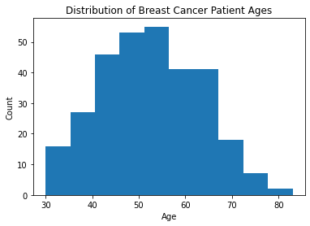

```python
#Set up plot
fig, ax = plt.subplots()

#Labels
ax.set_title("Distribution of Breast Cancer Patient Ages")
ax.set_xlabel("Age")
ax.set_ylabel("Count")

#Create actual plot and display
ax.hist(data['age'])
fig.show()
```

The distribution looks roughly normal, though perhaps slightly skewed to the right.

### Operation Year

Next we take a look at what year the breast cancer surgery took place. We can visualize this with a histogram.

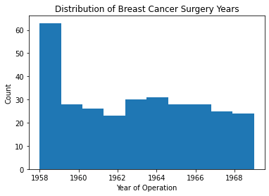

```python
#Set up plot
fig, ax = plt.subplots()

#Labels
ax.set_title("Distribution of Breast Cancer Surgery Years")
ax.set_xlabel("Year of Operation")
ax.set_ylabel("Count")

#Create actual plot and display
ax.hist(data['year_op'])
fig.show()
```

### Number of positive axillary nodes

Now we examine how many positive lymph nodes were detected in the patients.

```python
print("Min: ", data['nodes'].min())
print("Mean (standard deviation): ", data['nodes'].mean(), "(", data['nodes'].std(),")")
print("Median: ", data['nodes'].median())
print("Max: ", data['nodes'].max())
```

```
Min:  0
Mean (standard deviation):  4.026143790849673 ( 7.189653506248565 )
Median:  1.0
Max:  52
```

There seems to be a fairly large spread. The least number of positive nodes is 0 and the most is 52. The data is likely skewed to the right due to mean being larger than median.

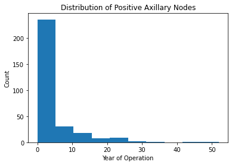

```python
#Set up plot
fig, ax = plt.subplots()

#Labels
ax.set_title("Distribution of Positive Axillary Nodes")
ax.set_xlabel("Year of Operation")
ax.set_ylabel("Count")

#Create actual plot and display
ax.hist(data['nodes'])
fig.show()
```

This distribution appears very much skewed to the right. The majority of participants had between 0 and 5 positive nodes.

Let's see the version of this data where we dichotomized having positive lymph nodes vs not having any.

We can count the number of participants with at least 1 positive node by counting the number of ones in this column.

```python
print("Number of patients with >=1 positive node: ", sum(data['nodes_binary']))
```

```
Number of patients with >=1 positive node:  170
```

Now let's plot the number in each category to see how many patients had positive lymph nodes.

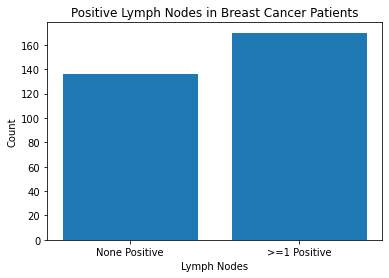

```python
#Set up plot
fig, ax = plt.subplots()

#Labels
ax.set_title("Positive Lymph Nodes in Breast Cancer Patients")
ax.set_xlabel("Lymph Nodes")
ax.set_ylabel("Count")

#Create actual plot and display
ax.bar(['None Positive', '>=1 Positive'], [sum(data['nodes_binary'] == 0), sum(data['nodes_binary'] == 1)])
fig.show()
```

There are slightly fewer patients who had no positive lymph nodes than there were patients with positive lymph nodes

### Survival Status

Finally let's take a look at how many patients survived past 5 years and how many did not. We can visuzalize this with a bar chart.

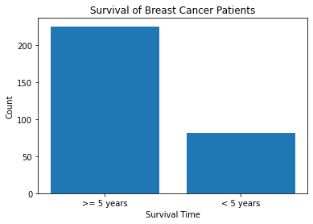

```python
#Set up plot
fig, ax = plt.subplots()

#Labels
ax.set_title("Survival of Breast Cancer Patients")
ax.set_xlabel("Survival Time")
ax.set_ylabel("Count")

#Create actual plot and display
ax.bar(['>= 5 years', '< 5 years'], [sum(data['surv'] == 0), sum(data['surv'] == 1)])
fig.show()
```

It seems the majority of participants survived at least 5 years after surgery.

### *Exploratory trends/patterns*

Now that we've taken a look at each variable, let's see if we can see any patterns, qualitatively. We want to learn more about predictors of survival in order to gain insight about prognosis for the disease. Here, we will look into whether patients survived past 5 years after their surgery (post-op) and consider how other factors might be related/associated with that survival.

### How has rate of survival past 5 years changed over time?

It would be interesting to see, with the development of new surgical techniques and treatments over time, if survival rates have increased. Let's group the data by year and compare the percentage of patients surviving at least 5 years in each time point.

```python
#Group data by year, getting a list of survival statuses for each year
data_by_year = data.groupby(data['year_op'], 0).surv.apply(list).reset_index()

#Count how many 1's and 0's in each year
surv_at_least_5 = list()
less_than_5 = list()
for i, row in data_by_year.iterrows():
    surv_at_least_5.append((row['surv']).count(0))
    less_than_5.append((row['surv']).count(1))
data_by_year['surv_at_least_5'] = surv_at_least_5
data_by_year['less_than_5'] = less_than_5

#Calculate percentage survivng at least 5 years
data_by_year['percent_at_least_5'] = 100 * data_by_year['surv_at_least_5'] / (data_by_year['surv_at_least_5'] + data_by_year['less_than_5'])
data_by_year
```

|  | year_op | surv | surv_at_least_5 | less_than_5 | percent_at_least_5 |
| --- | --- | --- | --- | --- | --- |
| 0 | 1958 | [0, 0, 0, 0, 0, 0, 0, 0, 1, 1, 1, 0, 0, 1, 1, ... | 24 | 12 | 66.666667 |
| 1 | 1959 | [0, 1, 0, 0, 0, 0, 0, 1, 0, 1, 0, 0, 0, 1, 1, ... | 18 | 9 | 66.666667 |
| 2 | 1960 | [0, 0, 0, 0, 0, 0, 0, 0, 0, 1, 0, 0, 0, 0, 0, ... | 24 | 4 | 85.714286 |
| 3 | 1961 | [0, 0, 0, 0, 0, 0, 0, 0, 0, 0, 0, 0, 0, 1, 0, ... | 23 | 3 | 88.461538 |
| 4 | 1962 | [0, 0, 0, 1, 0, 1, 0, 0, 0, 1, 0, 0, 0, 0, 1, ... | 16 | 7 | 69.565217 |
| 5 | 1963 | [0, 0, 0, 0, 0, 0, 0, 0, 1, 0, 0, 1, 0, 1, 0, ... | 22 | 8 | 73.333333 |
| 6 | 1964 | [0, 0, 0, 1, 0, 1, 1, 0, 0, 1, 0, 0, 1, 1, 0, ... | 23 | 8 | 74.193548 |
| 7 | 1965 | [0, 0, 0, 0, 0, 0, 0, 1, 1, 1, 0, 0, 0, 1, 1, ... | 15 | 13 | 53.571429 |
| 8 | 1966 | [1, 0, 0, 1, 0, 1, 0, 0, 0, 0, 0, 0, 1, 0, 0, ... | 22 | 6 | 78.571429 |
| 9 | 1967 | [0, 0, 0, 1, 0, 1, 0, 0, 0, 1, 0, 0, 0, 0, 0, ... | 21 | 4 | 84.000000 |
| 10 | 1968 | [0, 0, 0, 1, 1, 1, 0, 0, 0, 0, 0, 0, 0] | 10 | 3 | 76.923077 |
| 11 | 1969 | [0, 1, 0, 1, 1, 1, 0, 0, 0, 0, 0] | 7 | 4 | 63.636364 |

Let's create a line plot to more clearly see how the percentage has changed over each year.

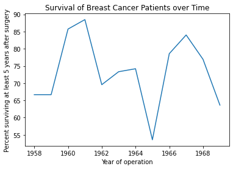

```python
#Set up plot
fig, ax = plt.subplots()

#labels
ax.set_title("Survival of Breast Cancer Patients over Time")
ax.set_xlabel("Year of operation")
ax.set_ylabel("Percent surviving at least 5 years after surgery")

#Create a line graph tracking the survival rate of patients over time
ax.plot(data_by_year['year_op'], data_by_year['percent_at_least_5'])
fig.show()
```

Survival rate of at least 5 years was highest in 1961 and lowest in 1965. There does not appear to be an obvious trend over time.

### Is the patient's age related to survival?

Age often plays a role in diseases, as it affects factors like our immune system. Here, let's take a look to see if age is related to survival of patients post-op.

```python
#Group data by survival status, creating a list of ages for each survival status
age_per_surv_status = data.groupby(data['surv'], 0).age.apply(list).reset_index()['age']

#Get a list of survival statuses matching the previous list
surv_status = data.groupby(data['surv'], 0).nodes.apply(list).reset_index()['surv']
```

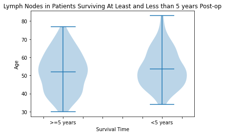

```python
#Set up plot
fig, ax = plt.subplots()

#labels
ax.set_title("Lymph Nodes in Patients Surviving At Least and Less than 5 years Post-op")
ax.set_xlabel("Survival Time")
ax.set_ylabel("Age")

#Create actual violin plot
ax.violinplot(age_per_surv_status, surv_status, showmeans = True)

#Label x axis of violin plot
labels = [item.get_text() for item in ax.get_xticklabels()]
labels[2] = ">=5 years"
labels[7] = "<5 years"
ax.set_xticklabels(labels)

fig.show()
```

Both distributions look roughly unimodal. The one for <5 years appears slightly skewed to the right. We cannot definitively tell if the distributions are normal just yet (more on this later). The ages for the <5 year survivors might be slightly shifted up compared to the >=5 year survivors.

### Is there a relationship between number of positive lymph nodes and survival status?

Since lymph nodes provide a way for cancer to spread to the rest of our body, it would be worthwhile to take a look at if the number of positive lymph nodes tells us anything about survival status. Here we create a violin plot to see distribution of lymph nodes for patients who survived at least and less than 5 years.

```python
#Group data by survival status, creating a list of nodes for each survival status
nodes_per_surv_status = data.groupby(data['surv'], 0).nodes.apply(list).reset_index()['nodes']

#Get a list of survival statuses matching the previous list
surv_status = data.groupby(data['surv'], 0).nodes.apply(list).reset_index()['surv']
```

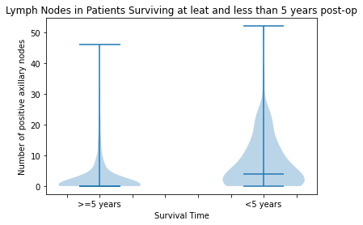

```python
#Set up plot
fig, ax = plt.subplots()

#Labels
ax.set_title("Lymph Nodes in Patients Surviving at leat and less than 5 years post-op")
ax.set_xlabel("Survival Time")
ax.set_ylabel("Number of positive axillary nodes")

#Create actual violin plot
ax.violinplot(nodes_per_surv_status, surv_status, showmedians = True)

#Label x axis of violin plot
labels = [item.get_text() for item in ax.get_xticklabels()]
labels[2] = ">=5 years"
labels[7] = "<5 years"
ax.set_xticklabels(labels)

fig.show()
```

Both distributions appear skewed to the right. The center for the < 5 year survival patients seems to be greater, suggesting those that did not survive past 5 years had more positive axillary lymph nodes.

Let's consider this question again when using the dichotomized lymph nodes variable (0 = none positive, 1 = at least 1 positive). Does having at least one positive lymph node tell us anything about survival? We can compare the percentage of those with at least one positive lymph node between the two survival status groups

```python
#Subset data by survival status
surv_at_least_5 = data[data['surv'] == 0]
less_than_5 = data[data['surv'] == 1]

#Count number of patients with at least 1 positive node and people with 0 positive nodes
nodes_surv_at_least_5 = list(surv_at_least_5.groupby('nodes_binary').count()['surv'])
nodes_less_than_5 = list(less_than_5.groupby('nodes_binary').count()['surv'])
```

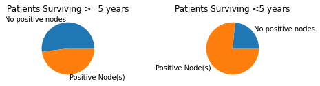

```python
#Set up figures
fig, (ax1, ax2) = plt.subplots(1,2)

#First pie chart for >=5 year survivors
ax1.set_title("Patients Surviving >=5 years")
ax1.pie(nodes_surv_at_least_5, labels = ["No positive nodes", "Positive Node(s)"])

#Second pie chart for <5 year survivors
ax2.set_title("Patients Surviving <5 years")
ax2.pie(nodes_less_than_5, labels = ["No positive nodes", "Positive Node(s)"])

#Display
fig.subplots_adjust(wspace=1.5)
fig.show()
```

There is over twice the percentage of patients who had no positive nodes in the >=5 year survivors compared to the <5 year survivors. Having positive axillary nodes may be predictve of a shorter survival time.

## Step 4: Hypothesis testing and machine learning

Now, let's use some statistics to show quantitative evidence on whether some of the above relationships exist.

### Is there a statistically significant difference in mean age between the two survival groups?

Here are our hypotheses:

- $H_0:$ the mean age of the two survival groups are equal
- $H_a:$ the mean age of the two survival groups are not equal

To test these hypotheses, we could use use a [two-sample t-test](https://www.jmp.com/en_us/statistics-knowledge-portal/t-test/two-sample-t-test.html). However, there are several assumptions that must be met for us to apply the t-test. We will asssume the samples are independent. We also have to check for normality. We did a visual check of this earlier in the exploration phase with the violin plots and it looked like there was a possibility of a skewed distribution. Let's do a [Shapiro-Wilk test](https://en.wikipedia.org/wiki/Shapiro%E2%80%93Wilk_test) to check if the distributions are normal.

```python
#Group age data by survival status
ages_for_surv_group = data.groupby(data['surv'], 0).age.apply(list).reset_index()
```

```python
#Perform test for normality
print(stats.shapiro(np.array(ages_for_surv_group['age'][0])))
print(stats.shapiro(np.array(ages_for_surv_group['age'][1])))
```

```
ShapiroResult(statistic=0.9842116236686707, pvalue=0.013179867528378963)
ShapiroResult(statistic=0.9763393402099609, pvalue=0.13881994783878326)
```

One of the distributions has a p-value of < 0.05. This means this sample distribution is not normal, so we cannot use a parametric statistical test.

Instead, let's use the non-parametric [Wilcoxon-Mann-Whitney test](https://en.wikipedia.org/wiki/Mann%E2%80%93Whitney_U_test) that does not assume normality.

```python
stats.mannwhitneyu(ages_for_surv_group['age'][0], ages_for_surv_group['age'][1])
```

```
MannwhitneyuResult(statistic=8446.0, pvalue=0.16459031990274325)
```

### Are number of positive lymph nodes associated with survival status?

Here are our hypotheses:

- $H_0:$ there is no association between number of positive nodes and survival status
- $H_a:$ there is an association between number of positive nodes and survival status

To test these hypotheses, we will use a logistic regression model to predict a binary outcome. You can read more about logistic regression [here](https://en.wikipedia.org/wiki/Logistic_regression).

Here, we will use machine learning to fit this model. The dataset we have will serve as a training set, and the algorithm will attempt to fit the model based on that.

```python
#Independent variable is number of nodes, dependent is survival status
ind = [[i] for i in data['nodes']]
dep = data['surv'].tolist()

#Fit logistic regression model using machine learning
reg = LogisticRegression().fit(ind, dep)

#Get regression coefficient
reg.coef_
```

```
array([[0.08574222]])
```

For logistic regression, the coefficient is actually the log of the odds ratio, so we must exponentiate it to get the actual [odds ratio](https://www.ncbi.nlm.nih.gov/pmc/articles/PMC2938757/).

```python
math.exp(reg.coef_)
```

```
1.0895254353100103
```

This tells us that with each additional positive axillary lymph node, there is a ~8.95% increased chance that patient will not survive past 5 years after surgery.

*Cross-validation*

Fitting the logistic regression model to the entire dataset does not tell us much about how the model would do for data it has never seen before. Because of this, it is useful to do cross-validation. In this case, we only train the algorithm on a subset of the dataset, and use the rest of the dataset to test out how the model did. Here, we will do 10-fold cross-validation, in which we split the dataset into 10 subsets, comparing one subset to the remaining 9 each time.

```python
#Loop over each fold
kf = KFold(n_splits=10)

#make list to store coefficients and accuracies
coefficients = list()
accuracies = list()

for train_index, test_index in kf.split(ind):

    #Split up datset into training and test data
    X_train, X_test = np.array(ind)[train_index], np.array(ind)[test_index]
    y_train, y_test = [dep[i] for i in train_index], [dep[i] for i in test_index]


    # Fit the logistic regression
    reg = LogisticRegression().fit(X_train, y_train)

    #See how we did
    predicted = reg.predict(X_test)
    actual = np.array(y_test)
    predictions = np.array(predicted)

    #Add coefficients and accuracy scores to the list
    coefficients.append(reg.coef_)
    accuracies.append(met.accuracy_score(actual, predictions))

    #Print out results
    print("Coefficient: ", reg.coef_)
    print("Confusion Matrix: \n", met.confusion_matrix(actual, predictions))
    print("Accuracy: ", met.accuracy_score(actual, predictions), "\n")
```

```
Coefficient:  [[0.09101072]]
Confusion Matrix:
 [[26  2]
 [ 2  1]]
Accuracy:  0.8709677419354839

Coefficient:  [[0.08967672]]
Confusion Matrix:
 [[24  1]
 [ 5  1]]
Accuracy:  0.8064516129032258

Coefficient:  [[0.08685254]]
Confusion Matrix:
 [[17  0]
 [11  3]]
Accuracy:  0.6451612903225806

Coefficient:  [[0.0785199]]
Confusion Matrix:
 [[23  0]
 [ 7  1]]
Accuracy:  0.7741935483870968

Coefficient:  [[0.08069482]]
Confusion Matrix:
 [[23  0]
 [ 8  0]]
Accuracy:  0.7419354838709677

Coefficient:  [[0.09286051]]
Confusion Matrix:
 [[16  3]
 [10  2]]
Accuracy:  0.5806451612903226

Coefficient:  [[0.07961657]]
Confusion Matrix:
 [[23  1]
 [ 5  1]]
Accuracy:  0.8

Coefficient:  [[0.08652353]]
Confusion Matrix:
 [[20  1]
 [ 7  2]]
Accuracy:  0.7333333333333333

Coefficient:  [[0.08832034]]
Confusion Matrix:
 [[20  2]
 [ 7  1]]
Accuracy:  0.7

Coefficient:  [[0.08559489]]
Confusion Matrix:
 [[23  0]
 [ 7  0]]
Accuracy:  0.7666666666666667
```

The [confusion matrices](https://towardsdatascience.com/visual-guide-to-the-confusion-matrix-bb63730c8eba) have non-zero numbers not part of the main diagonal. When this occurs, this means the model has incorrectly predicted some of the outcomes.

Let's get a summary of the coefficients and [accuracies](https://scikit-learn.org/stable/modules/generated/sklearn.metrics.accuracy_score.html):

```python
print("Average coefficient (standard deviation): ", np.array(coefficients).mean(), "(", np.array(coefficients).std(),")")
print("Average accuracy (standard deviation): ", np.array(accuracies).mean(), "(", np.array(accuracies).std(),")")
```

```
Average coefficient (standard deviation):  0.08596705341261086 ( 0.004659136748424159 )
Average accuracy (standard deviation):  0.7419354838709677 ( 0.07940261405338497 )
```

To determine if we can reject our null hypothesis, we must look at the confidence interval and p-value for the coefficient

```python
#Prepare independent and dependent variables for the model fit
x = np.array(data['nodes'])
X = sm.add_constant(x)
y = np.array(data['surv'])

#Fit logistic regression
reg = sm.Logit(y, X).fit()

#Print results
print(reg.summary())
```

```
Optimization terminated successfully.
         Current function value: 0.540398
         Iterations 5
                           Logit Regression Results
==============================================================================
Dep. Variable:                      y   No. Observations:                  306
Model:                          Logit   Df Residuals:                      304
Method:                           MLE   Df Model:                            1
Date:                Sun, 18 Jul 2021   Pseudo R-squ.:                 0.06493
Time:                        03:09:00   Log-Likelihood:                -165.36
converged:                       True   LL-Null:                       -176.84
Covariance Type:            nonrobust   LLR p-value:                 1.650e-06
==============================================================================
                 coef    std err          z      P>|z|      [0.025      0.975]
------------------------------------------------------------------------------
const         -1.4125      0.163     -8.667      0.000      -1.732      -1.093
x1             0.0858      0.020      4.387      0.000       0.047       0.124
==============================================================================
```

Again, to make more sense of the values, let's exponentiate the confidence interval log odds to get the odds ratios.

```python
print("95% Lower Bound: ", math.exp(0.047))
print("95% Lower Bound: ", math.exp(0.124))
```

```
95% Lower Bound:  1.0481220090796557
95% Lower Bound:  1.1320158709991752
```

The p-value is <0.05 and the confidence interval does not include 0. This means that we can reject our null hypothesis. We can say conclude that in the true population, there is between a 4.81% and 13.20% increased risk of passing away within 5 years for each additional positive lymph node, with 95% confidence.

What is the association between having *any* positive nodes and survival status? All we have to do for this is change the previous nodes variable to the dichotomized version and re-fit the model

```python
#Prepare independent and dependent variables for the model fit
x = np.array(data['nodes_binary'])
X = sm.add_constant(x)
y = np.array(data['surv'])

#Fit logistic regression
reg = sm.Logit(y, X).fit()

#Print results
print(reg.summary())
```

```
Optimization terminated successfully.
         Current function value: 0.544234
         Iterations 6
                           Logit Regression Results
==============================================================================
Dep. Variable:                      y   No. Observations:                  306
Model:                          Logit   Df Residuals:                      304
Method:                           MLE   Df Model:                            1
Date:                Sun, 18 Jul 2021   Pseudo R-squ.:                 0.05829
Time:                        03:09:01   Log-Likelihood:                -166.54
converged:                       True   LL-Null:                       -176.84
Covariance Type:            nonrobust   LLR p-value:                 5.610e-06
==============================================================================
                 coef    std err          z      P>|z|      [0.025      0.975]
------------------------------------------------------------------------------
const         -1.8177      0.247     -7.349      0.000      -2.303      -1.333
x1             1.2627      0.294      4.292      0.000       0.686       1.839
==============================================================================
```

```python
print("Odds Ratio: ", math.exp(1.2627))
print("95% Lower Bound: ", math.exp(0.686))
print("95% Lower Bound: ", math.exp(1.839))
```

```
Odds Ratio:  3.534952987115546
95% Lower Bound:  1.9857565995893263
95% Lower Bound:  6.2902448699855995
```

The odds ratio is even larger this time. The model predicts a 253.50% increased risk of death within 5 years for those with at least one positive lymph node. The 95% confidence interval for this estimate is between 98.58% and 529.02%.

## Step 5: Communication of insights attained

Overall, we learned:

- There does not appear to be a trend when it comes to percentage of breast cancer surgery patients survivng at least 5 years over time
- We do not have evidence to conclude there is a difference in mean age between patients who survived less than 5 years and those who survived at least 5 years
- We have evidence to believe that number of positive axillary nodes is associated with survival status
  - The odds ratio (95% confidence interval) for when number of nodes is treated as a *numerical* variable is 1.09 (1.05, 1.13)
  - The odds ratio (95% confidence interval) for when number of nodes is treated as a *categorical* variable is 3.53 (1.99, 6.29)

The final finding gives us insight about predicting prognosis of the cancer. Patients who have positive lymph nodes are less likely to survive at least 5 years, with a ~253% increased chance of dying within the first 5 years. More specifically, each additional positive lymph node increases the risk of dying within 5 years by ~9%.

## Further Reading

**APIs for modules used in this notebook:**

- [Pandas API](https://pandas.pydata.org/docs/reference/index.html)
- [Numpy API](https://numpy.org/doc/stable/reference/)
- [Matplotlib API](https://matplotlib.org/stable/api/index.html)
- [SciPy API](https://docs.scipy.org/doc/scipy/reference/)
- [Math API](https://docs.python.org/3/library/math.html)
- [Statsmodels API](https://www.statsmodels.org/stable/api.html)
- [Scikit Learn API](https://scikit-learn.org/stable/modules/classes.html)

**Cancer Information:**

- [American Cancer Society](https://www.cancer.org/)
- [National Cancer Institute](https://www.cancer.gov/)

**Statistics resources:**

- [Statistical methods and common problems in medical or biomedical science research](https://www.ncbi.nlm.nih.gov/pmc/articles/PMC5698693/)
- [Tutorials Point](https://www.tutorialspoint.com/statistics/index.htm)
- [American American Statistical Association Statement on p-Values: Context, Process, and Purpose](https://www.tandfonline.com/doi/full/10.1080/00031305.2016.1154108)

**More on the data science pipeline:**

- [A Beginner's Guide](https://towardsdatascience.com/a-beginners-guide-to-the-data-science-pipeline-a4904b2d8ad3)
- [GeeksforGeeks](https://www.geeksforgeeks.org/whats-data-science-pipeline/)